# Analiza danych - projekt zaliczeniowy

A. Grotowski, M. Mądrawski. S. Węgorzewski

27 czerwca 2018

### Źródło zbioru danych

**[UCI Machine Learning Repository](http://archive.ics.uci.edu/ml/datasets/Adult)**  
*Zbiór:* **Adult** - dostępny pod adresem http://archive.ics.uci.edu/ml/datasets/Adult.  
*Zmienna zależna:* **Class**

## I. Opis zbioru

### 1. Dane

Zestaw danych **Adult** został wyodrębniony w 1994 roku z danych spisu powszechnego w Stanach Zjednoczonych. Zawiera atrybuty ciągłe i nominalne, opisujące niektóre informacje społeczne (wiek, rasa, płeć, stan cywilny, …) dotyczące zarejestrowanych obywateli.

### 2. Charakterystyka

- Typ: Klasyfikacja (Classification);
- Pochodzenie: Swiat rzeczywisty;
- Liczba prób: 45222 (48842);
- Liczba cech (zmiennych): 14;
- Liczba klas: 2;
- Brakujące wartościci: Tak.

### 3. Opis zmiennych

Zestaw danych Adult posiada 14 zmiennych wejściowych (niezależnych) i 1 zmienną wyjściową (zależną).

**Zmienne wejściowe (niezależne):**

1. Age: [17.0, 90.0];
2. Worklass: {Private, Self-emp-not-inc, Self-emp-inc, Federal-gov, Local-gov, State-gov, Without-pay, Never-worked};
3. Fnlwgt: [12285.0, 1490400.0];
4. Education: {Bachelors, Some-college, 11th, HS-grad, Prof-school, Assoc-acdm, Assoc-voc, 9th, 7th-8th, 12th, Masters, 1st-4th, 10th, Doctorate, 5th-6th, Preschool};
5. Education-num: [1.0, 16.0];
6. Marital-status: {Married-civ-spouse, Divorced, Never-married, Separated, Widowed, Married-spouse-absent, Married-AF-spouse};
7. Occupation: {Tech-support, Craft-repair, Other-service, Sales, Exec-managerial, Prof-specialty, Handlers-cleaners, Machine-op-inspct, Adm-clerical, Farming-fishing, Transport-moving, Priv-house-serv, Protective-serv, Armed-Forces};
8. Relationship: {Wife, Own-child, Husband, Not-in-family, Other-relative, Unmarried};
9. Race: {White, Asian-Pac-Islander, Amer-Indian-Eskimo, Other, Black};
10. Sex: {Female, Male};
11. Capital.gain: [0.0, 99999.0];
12. Capital.loss: [0.0, 4356.0];
13. Hours.per.week: [1.0, 99.0];
14. Native.country: {United-States, Cambodia, England, Puerto-Rico, Canada, Germany, Outlying-US(Guam-USVI-etc), India, Japan, Greece, South, China, Cuba, Iran, Honduras, Philippines, Italy, Poland, Jamaica, Vietnam, Mexico, Portugal, Ireland, France, Dominican-Republic, Laos, Ecuador, Taiwan, Haiti, Columbia, Hungary, Guatemala, Nicaragua, Scotland, Thailand, Yugoslavia, El-Salvador, Trinadad&Tobago, Peru, Hong, Holand-Netherlands}.

**Zmienna wyjściowa (zależna):**

1. SalaryClass: {>50K, <=50K}.

### 4. Cel zadania

**Zadanie polega na przewidywaniu, czy dochód obywatela przekracza pięćdziesiąt tysięcy dolarów rocznie.**

## II. Przygotowanie zbioru danych

### 1. Wczytanie zbioru danych

```r
adult <- read.csv2('adult.csv', header = TRUE, sep = ";")
```

Prezentacja struktury zbioru danych

```r
str(adult)
```

```
## 'data.frame':    48842 obs. of  15 variables:
##  $ Age           : int  25 38 28 44 18 34 29 63 24 55 ...
##  $ Workclass     : Factor w/ 9 levels "?","Federal-gov",..: 5 5 3 5 1 5 1 7 5 5 ...
##  $ Fnlwgt        : int  226802 89814 336951 160323 103497 198693 227026 104626 369667 104996 ...
##  $ Education     : Factor w/ 16 levels "10th","11th",..: 2 12 8 16 16 1 12 15 16 6 ...
##  $ Education.num : int  7 9 12 10 10 6 9 15 10 4 ...
##  $ Marital.status: Factor w/ 7 levels "Divorced","Married-AF-spouse",..: 5 3 3 3 5 5 5 3 5 3 ...
##  $ Occupation    : Factor w/ 15 levels "?","Adm-clerical",..: 8 6 12 8 1 9 1 11 9 4 ...
##  $ Relationship  : Factor w/ 6 levels "Husband","Not-in-family",..: 4 1 1 1 4 2 5 1 5 1 ...
##  $ Race          : Factor w/ 5 levels "Amer-Indian-Eskimo",..: 3 5 5 3 5 5 3 5 5 5 ...
##  $ Sex           : Factor w/ 2 levels "Female","Male": 2 2 2 2 1 2 2 2 1 2 ...
##  $ Capital.gain  : int  0 0 0 7688 0 0 0 3103 0 0 ...
##  $ Capital.loss  : int  0 0 0 0 0 0 0 0 0 0 ...
##  $ Hours.per.week: int  40 50 40 40 30 30 40 32 40 10 ...
##  $ Native.country: Factor w/ 42 levels "?","Cambodia",..: 40 40 40 40 40 40 40 40 40 40 ...
##  $ SalaryClass   : Factor w/ 2 levels "<=50K",">50K": 1 1 2 2 1 1 1 2 1 1 ...
```

Prezentacja podsumowania zbioru danych

```r
summary(adult)
```

```
##       Age                   Workclass         Fnlwgt
##  Min.   :17.00   Private         :33906   Min.   :  12285
##  1st Qu.:28.00   Self-emp-not-inc: 3862   1st Qu.: 117551
##  Median :37.00   Local-gov       : 3136   Median : 178145
##  Mean   :38.64   ?               : 2799   Mean   : 189664
##  3rd Qu.:48.00   State-gov       : 1981   3rd Qu.: 237642
##  Max.   :90.00   Self-emp-inc    : 1695   Max.   :1490400
##                  (Other)         : 1463
##         Education     Education.num                 Marital.status
##  HS-grad     :15784   Min.   : 1.00   Divorced             : 6633
##  Some-college:10878   1st Qu.: 9.00   Married-AF-spouse    :   37
##  Bachelors   : 8025   Median :10.00   Married-civ-spouse   :22379
##  Masters     : 2657   Mean   :10.08   Married-spouse-absent:  628
##  Assoc-voc   : 2061   3rd Qu.:12.00   Never-married        :16117
##  11th        : 1812   Max.   :16.00   Separated            : 1530
##  (Other)     : 7625                   Widowed              : 1518
##            Occupation            Relationship                   Race
##  Prof-specialty : 6172   Husband       :19716   Amer-Indian-Eskimo:  470
##  Craft-repair   : 6112   Not-in-family :12583   Asian-Pac-Islander: 1519
##  Exec-managerial: 6086   Other-relative: 1506   Black             : 4685
##  Adm-clerical   : 5611   Own-child     : 7581   Other             :  406
##  Sales          : 5504   Unmarried     : 5125   White             :41762
##  Other-service  : 4923   Wife          : 2331
##  (Other)        :14434
##      Sex         Capital.gain    Capital.loss    Hours.per.week
##  Female:16192   Min.   :    0   Min.   :   0.0   Min.   : 1.00
##  Male  :32650   1st Qu.:    0   1st Qu.:   0.0   1st Qu.:40.00
##                 Median :    0   Median :   0.0   Median :40.00
##                 Mean   : 1079   Mean   :  87.5   Mean   :40.42
##                 3rd Qu.:    0   3rd Qu.:   0.0   3rd Qu.:45.00
##                 Max.   :99999   Max.   :4356.0   Max.   :99.00
##
##        Native.country  SalaryClass
##  United-States:43832   <=50K:37155
##  Mexico       :  951   >50K :11687
##  ?            :  857
##  Philippines  :  295
##  Germany      :  206
##  Puerto-Rico  :  184
##  (Other)      : 2517
```

### 2. Konwersja

Zmienne **Occupation**, **Workclass** oraz **Native-country**, zawierają braki danych reprezentowane jako znak “?”. Pojawianie się tego znaku powoduje zwiekszenie liczby faktorów dla poszczególnych zmiennych. Dlatego też należy zamienić znak “?” na watość “NA” (ang. *Not Available*).

Konwersja znakóW “**?**” na “**NA**”.

```r
adult[adult == "?"] <- NA
head(is.na(adult), 5)
```

```
##        Age Workclass Fnlwgt Education Education.num Marital.status
## [1,] FALSE     FALSE  FALSE     FALSE         FALSE          FALSE
## [2,] FALSE     FALSE  FALSE     FALSE         FALSE          FALSE
## [3,] FALSE     FALSE  FALSE     FALSE         FALSE          FALSE
## [4,] FALSE     FALSE  FALSE     FALSE         FALSE          FALSE
## [5,] FALSE      TRUE  FALSE     FALSE         FALSE          FALSE
##      Occupation Relationship  Race   Sex Capital.gain Capital.loss
## [1,]      FALSE        FALSE FALSE FALSE        FALSE        FALSE
## [2,]      FALSE        FALSE FALSE FALSE        FALSE        FALSE
## [3,]      FALSE        FALSE FALSE FALSE        FALSE        FALSE
## [4,]      FALSE        FALSE FALSE FALSE        FALSE        FALSE
## [5,]       TRUE        FALSE FALSE FALSE        FALSE        FALSE
##      Hours.per.week Native.country SalaryClass
## [1,]          FALSE          FALSE       FALSE
## [2,]          FALSE          FALSE       FALSE
## [3,]          FALSE          FALSE       FALSE
## [4,]          FALSE          FALSE       FALSE
## [5,]          FALSE          FALSE       FALSE
```

### 3. Uzupełnienie zbiorów danych

Prezentacja informacji o brakujących danych

```
##            Age      Workclass         Fnlwgt      Education  Education.num
##              0           2799              0              0              0
## Marital.status     Occupation   Relationship           Race            Sex
##              0           2809              0              0              0
##   Capital.gain   Capital.loss Hours.per.week Native.country    SalaryClass
##              0              0              0            857              0
```

[output not shown]

[output not shown]

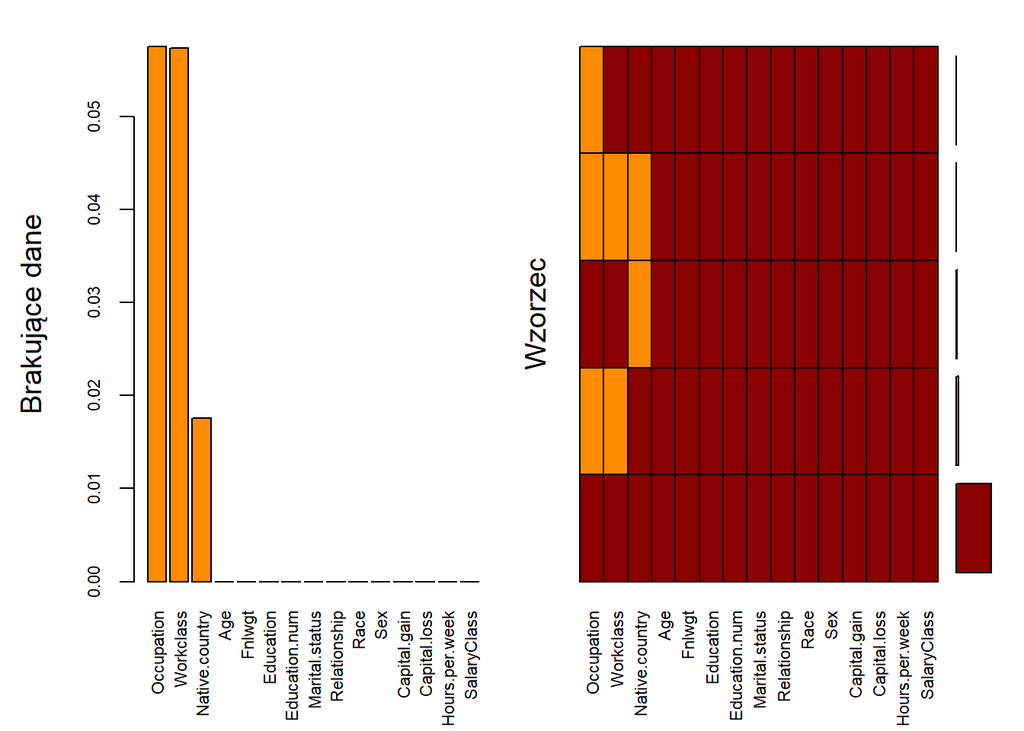

```
##
##  Variables sorted by number of missings:
##        Variable      Count
##      Occupation 0.05751198
##       Workclass 0.05730724
##  Native.country 0.01754637
##             Age 0.00000000
##          Fnlwgt 0.00000000
##       Education 0.00000000
##   Education.num 0.00000000
##  Marital.status 0.00000000
##    Relationship 0.00000000
##            Race 0.00000000
##             Sex 0.00000000
##    Capital.gain 0.00000000
##    Capital.loss 0.00000000
##  Hours.per.week 0.00000000
##     SalaryClass 0.00000000
```

Braki danych dotyczą atrybutów typu factor. Została podjęta decyzcja o uzupełnieniu brakujacych danych przed podziałem zbioru na podzbiory.

```
##            Age      Workclass         Fnlwgt      Education  Education.num
##              0              0              0              0              0
## Marital.status     Occupation   Relationship           Race            Sex
##              0              0              0              0              0
##   Capital.gain   Capital.loss Hours.per.week Native.country    SalaryClass
##              0              0              0              0              0
```

### 4. Podział zbioru na podzbiory - 60, 20, 20

Zbiór **Adult** został podzielony na podziory:

- **adult_train** - zbiór treningowy (uczący) zawierający 60% wszystkich prób
- **adult_test** - zbiór testowy zawierający 20% wszystkich prób
- **adult_ver** - zbiór do weryfikacji zawierający 20% wszystkich prób

```
##  [1]  TRUE FALSE  TRUE FALSE FALSE  TRUE  TRUE  TRUE FALSE  TRUE  TRUE
## [12] FALSE FALSE  TRUE  TRUE
```

```
##  [1] FALSE FALSE  TRUE FALSE FALSE  TRUE  TRUE FALSE  TRUE  TRUE FALSE
## [12] FALSE FALSE  TRUE  TRUE
```

## III. Regresja logistyczna

```r
model_1 <- glm(SalaryClass ~ . , data = adult_train, family = 'binomial')
summary(model_1)
```

```
##
## Call:
## glm(formula = SalaryClass ~ ., family = "binomial", data = adult_train)
##
## Deviance Residuals:
##     Min       1Q   Median       3Q      Max
## -5.0333  -0.5081  -0.1875  -0.0217   4.0769
##
## Coefficients: (3 not defined because of singularities)
##                                            Estimate Std. Error   z value
## (Intercept)                              -5.770e+11  2.300e+12    -0.251
## Age                                       2.330e-02  1.710e-03    13.631
## WorkclassFederal-gov                      5.770e+11  2.300e+12     0.251
## WorkclassLocal-gov                        5.770e+11  2.300e+12     0.251
## WorkclassNever-worked                    -4.503e+15  2.300e+12 -1957.450
## WorkclassPrivate                          5.770e+11  2.300e+12     0.251
## WorkclassSelf-emp-inc                     5.770e+11  2.300e+12     0.251
## WorkclassSelf-emp-not-inc                 5.770e+11  2.300e+12     0.251
## WorkclassState-gov                        5.770e+11  2.300e+12     0.251
## WorkclassWithout-pay                      5.770e+11  2.300e+12     0.251
## Fnlwgt                                    7.089e-07  1.765e-07     4.017
## Education11th                            -1.126e-01  2.259e-01    -0.498
## Education12th                             5.728e-01  2.717e-01     2.108
## Education1st-4th                         -7.643e-01  6.012e-01    -1.271
## Education5th-6th                         -4.077e-01  3.541e-01    -1.151
## Education7th-8th                         -3.228e-01  2.358e-01    -1.369
## Education9th                             -3.392e-01  2.781e-01    -1.220
## EducationAssoc-acdm                       1.590e+00  1.859e-01     8.554
## EducationAssoc-voc                        1.440e+00  1.787e-01     8.057
## EducationBachelors                        2.103e+00  1.667e-01    12.617
## EducationDoctorate                        3.210e+00  2.245e-01    14.299
## EducationHS-grad                          8.365e-01  1.625e-01     5.147
## EducationMasters                          2.511e+00  1.772e-01    14.172
## EducationPreschool                       -2.358e+01  4.318e+04    -0.001
## EducationProf-school                      3.080e+00  2.111e-01    14.592
## EducationSome-college                     1.220e+00  1.650e-01     7.392
## Education.num                                    NA         NA        NA
## Marital.statusMarried-AF-spouse           2.650e+00  5.520e-01     4.801
## Marital.statusMarried-civ-spouse          2.592e+00  2.676e-01     9.689
## Marital.statusMarried-spouse-absent       3.373e-01  2.206e-01     1.529
```

[output cut: 168 more lines]

```
## Native.countryThailand                    0.13057
## Native.countryTrinadad&Tobago             0.99975
## Native.countryUnited-States               0.65112
## Native.countryVietnam                     0.03708 *
## Native.countryYugoslavia                       NA
## ---
## Signif. codes:  0 '***' 0.001 '**' 0.01 '*' 0.05 '.' 0.1 ' ' 1
##
## (Dispersion parameter for binomial family taken to be 1)
##
##     Null deviance: 32344  on 29304  degrees of freedom
## Residual deviance: 18724  on 29207  degrees of freedom
## AIC: 18920
##
## Number of Fisher Scoring iterations: 25
```

Ze względu na dużą ilość poziomów poszczególnych zmiennych, model regresji logistycznej nie jest adekwatny dla wykorzystywanego zbioru Adult. Zbiór powinien zostać odpowiednio przeprojektowany w celu zmniejszenia liczby poziomów.

## IV. Drzewo decyzyjne

### 1. Wariant A

```r
library(rpart)
library(rpart.plot)
tree.adult_model_A <- rpart(SalaryClass~., data=adult_train, method = "class")
tree.adult_model_A
```

```
## n= 29305
##
## node), split, n, loss, yval, (yprob)
##       * denotes terminal node
##
##  1) root 29305 7053 <=50K (0.75932435 0.24067565)
##    2) Relationship=Not-in-family,Other-relative,Own-child,Unmarried 16006 1059 <=50K (0.93383731 0.06616269)
##      4) Capital.gain< 7073.5 15724  790 <=50K (0.94975833 0.05024167) *
##      5) Capital.gain>=7073.5 282   13 >50K (0.04609929 0.95390071) *
##    3) Relationship=Husband,Wife 13299 5994 <=50K (0.54928942 0.45071058)
##      6) Education=10th,11th,12th,1st-4th,5th-6th,7th-8th,9th,Assoc-voc,HS-grad,Preschool,Some-college 8877 2896 <=50K (0.67376366 0.32623634)
##       12) Capital.gain< 5095.5 8446 2473 <=50K (0.70719867 0.29280133) *
##       13) Capital.gain>=5095.5 431    8 >50K (0.01856148 0.98143852) *
##      7) Education=Assoc-acdm,Bachelors,Doctorate,Masters,Prof-school 4422 1324 >50K (0.29941203 0.70058797) *
```

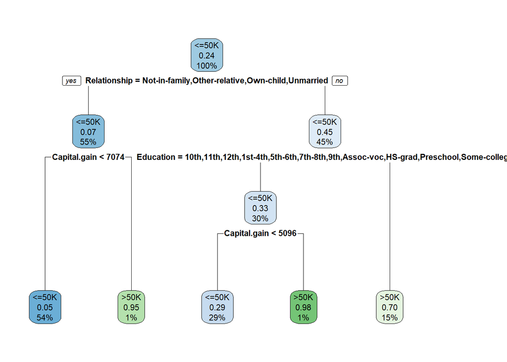

```r
rpart.plot(tree.adult_model_A)
```

#### 1.1 Interpretacja wyników

Drzewo wykorzystało tylko 3 z 14 dostępnych zmiennych. rpart automatycznie stosuje metodologię wyboru cech w celu wybrania niewielkiej liczby predyktorów do zbudowania drzewa.

## V. Lasy losowe

### 1. Wariant A - 5 drzew w lesie

```r
library(randomForest)
set.seed(123)
randomTree.adult_model_A <- randomForest(SalaryClass~., data=adult_train, importance=TRUE, ntree=5)
randomTree.adult_model_A
```

```
##
## Call:
##  randomForest(formula = SalaryClass ~ ., data = adult_train, importance = TRUE,      ntree = 5)
##                Type of random forest: classification
##                      Number of trees: 5
## No. of variables tried at each split: 3
##
##         OOB estimate of  error rate: 17.2%
## Confusion matrix:
##       <=50K >50K class.error
## <=50K 18051 1931  0.09663697
## >50K   2599 3759  0.40877634
```

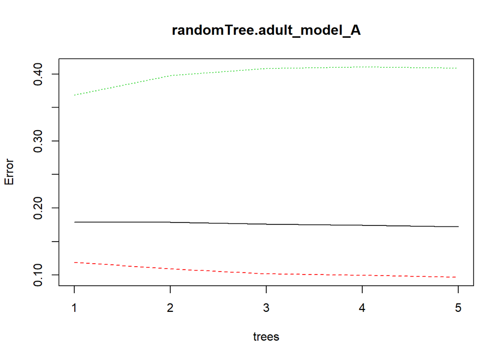

```r
plot(randomTree.adult_model_A)
```

### 2. Wariant B - 500 drzew w lesie

```r
set.seed(123)
randomTree.adult_model_B <- randomForest(SalaryClass~., data=adult_train, importance=TRUE, ntree=500)
randomTree.adult_model_B
```

```
##
## Call:
##  randomForest(formula = SalaryClass ~ ., data = adult_train, importance = TRUE,      ntree = 500)
##                Type of random forest: classification
##                      Number of trees: 500
## No. of variables tried at each split: 3
##
##         OOB estimate of  error rate: 13.68%
## Confusion matrix:
##       <=50K >50K class.error
## <=50K 20825 1427  0.06412907
## >50K   2581 4472  0.36594357
```

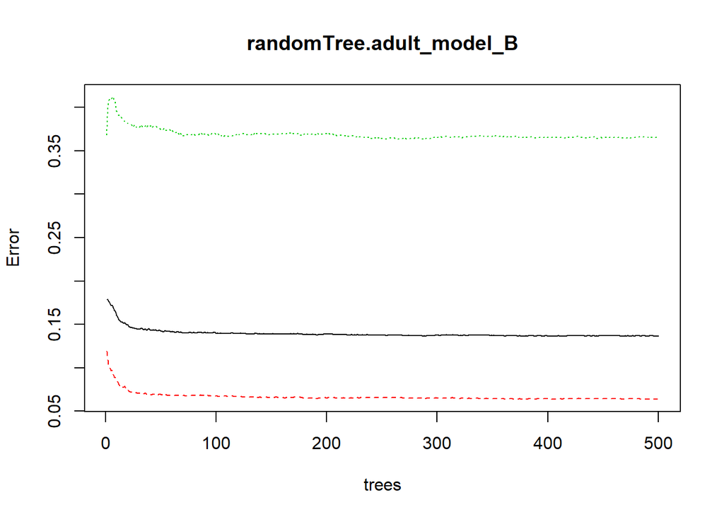

```r
plot(randomTree.adult_model_B)
```

### 3. Wariant C -1000 drzew w lesie

```r
library(randomForest)
set.seed(123)
randomTree.adult_model_C <- randomForest(SalaryClass~., data=adult_train, importance=TRUE, ntree=1000)
randomTree.adult_model_C
```

```
##
## Call:
##  randomForest(formula = SalaryClass ~ ., data = adult_train, importance = TRUE,      ntree = 1000)
##                Type of random forest: classification
##                      Number of trees: 1000
## No. of variables tried at each split: 3
##
##         OOB estimate of  error rate: 13.71%
## Confusion matrix:
##       <=50K >50K class.error
## <=50K 20811 1441  0.06475822
## >50K   2576 4477  0.36523465
```

[figure not shown]

```r
plot(randomTree.adult_model_B)
```